# Preprocessing of Montevideo’s injuries dataset

Daniel

2021-10-25

Note: in order to create the markdown properly from this file, Rstudio options need to be changed. Tools > Global Options > R Markdown > Evaluate chunks in directory > Current. By default this option is set to *Document*, but here you need to change it to *Current* so everything works as expected.

# **Preprocessing phase**

```
##           used (Mb) gc trigger  (Mb) max used (Mb)
## Ncells 1070009 57.2    2212758 118.2  1366964 73.1
## Vcells 1801306 13.8    8388608  64.0  2589177 19.8
```

## Importing datasets

I ran everything local because it is faster, but if someone wants to run this script, then only the path needs to be changed.

```r
# V-Drive folder
#path <- "V:/Studies/MOVED/HealthImpact/Data/Country/Chile/Injuries"
# Local folder
path <- "C:/Users/danie/Documents/Daniel_Gil/Consultorias/2021/Cambridge/Data/Uruguay/Montevideo/Injuries/"
```

```r
# Injuries
injuries <- read_excel(
  paste0(path, "Registro de incidentes viales 2018 2020 (1).xlsx"),
  sheet = "Personas involucradas", guess_max = 100000)
```

*Filtering only accidents with fatalities I idenfify the accident ID of fatalities to filter those rows as well as those involved in the accidents.

```r
names(injuries)
```

```
##  [1] "Fecha"
##  [2] "Edad"
##  [3] "Rol"
##  [4] "Calle"
##  [5] "Zona"
##  [6] "Tipo de resultado"
##  [7] "Tipo de siniestro"
##  [8] "Usa cinturón"
##  [9] "Usa casco"
## [10] "Día de la semana"
## [11] "Sexo"
## [12] "Hora"
## [13] "Departamento"
## [14] "Localidad"
## [15] "Novedad"
```

[output cut: 16 more lines]

```r
unique(injuries$`Tipo de resultado`)
```

```
## [1] "ILESO"                             "HERIDO LEVE"
## [3] "HERIDO GRAVE"                      "FALLECIDO EN EL LUGAR"
## [5] "FALLECIDO EN CENTRO DE ASISTENCIA"
```

```r
table(injuries$`Tipo de resultado`)
```

```
##
## FALLECIDO EN CENTRO DE ASISTENCIA             FALLECIDO EN EL LUGAR
##                               133                               167
##                      HERIDO GRAVE                       HERIDO LEVE
##                              2554                             20612
##                             ILESO
##                             28817
```

```r
id_fatalities <- injuries %>%
  filter(`Tipo de resultado` %in% c("FALLECIDO EN EL LUGAR",
                                    "FALLECIDO EN CENTRO DE ASISTENCIA"))
id_fatalities <- pull(id_fatalities, Novedad)  # There are 300 fatalities
length(unique(id_fatalities)) # There are in total 284 accidents with fatalities
```

```
## [1] 284
```

Filtering fatalities

```r
fatalities <- injuries %>% filter(Novedad %in% id_fatalities)
length(unique(fatalities$Novedad)) # Same 284 accidents
```

```
## [1] 284
```

```r
table(fatalities$`Tipo de resultado`) # Same 300 fatalities
```

```
##
## FALLECIDO EN CENTRO DE ASISTENCIA             FALLECIDO EN EL LUGAR
##                               133                               167
##                      HERIDO GRAVE                       HERIDO LEVE
##                                52                                86
##                             ILESO
##                               281
```

I took ” Vehiculo Víctima” variable and translated it

```r
main_mode <- read_excel("C:/Users/danie/Documents/Daniel_Gil/Consultorias/2020/WorldBank/Data/Uruguay/Hierarchy.xlsx", sheet = "Montevideo_injuries")
#main_mode %>% kbl() %>% kable_classic()
```

I import this file to standardize modes

```r
# Read lookup table
smodes <- read_csv('data/global/modes/standardized_modes.csv')
# Separate rows
smodes <- smodes %>% separate_rows(original, sep = ';')
# Trim
smodes <- smodes %>%
  mutate(across(where(is.character), str_trim))
```

Selecting the variables I need and creating new ones

```r
fatalities_v2 <- fatalities %>%
  dplyr::select("Fecha", "Novedad", "Tipo de resultado", "Tipo de siniestro",
                "Sexo", "Edad", "Vehiculo Víctima") %>%
  mutate(
    event_id = Novedad,
    year = (as.numeric(format(Fecha, "%Y"))),
    mode_type = main_mode$ITHIM[match(`Vehiculo Víctima`, main_mode$Mode)],
    hierarchy = main_mode$Hierarchy[match(`Vehiculo Víctima`, main_mode$Mode)],
    Edad = as.numeric(ifelse(Edad == "SIN DATOS", NA, Edad)))
```

Since the processing for casualty’s variables is different from strike ones, I do them in different datasets

```r
casualties <- fatalities_v2 %>%
  filter(`Tipo de resultado` %in% c("FALLECIDO EN EL LUGAR",
                                    "FALLECIDO EN CENTRO DE ASISTENCIA"))
strike <- fatalities_v2 %>%
  filter(!`Tipo de resultado` %in% c("FALLECIDO EN EL LUGAR",
                                     "FALLECIDO EN CENTRO DE ASISTENCIA"))
```

Create variables for casualties

```r
casualties <- casualties %>%
  mutate(cas_age = Edad,
         cas_gender = ifelse(Sexo == "MASCULINO", "Male",
                             ifelse(Sexo == "FEMENINO", "Female", NA)),
         cas_mode = mode_type)
```

Create variables for strike mode. For this I use the hierarchy when there’s more than 1 vehicle per accident

```r
strike <- strike %>%
  group_by(event_id) %>%
  mutate(min_mode = min(hierarchy),
         strike_mode = main_mode$ITHIM[match(min_mode, main_mode$Hierarchy)]) %>%
  ungroup()
```

Since I already identified the strike mode, I can delete duplicates

```r
strike_v2 <- strike[!duplicated(strike$event_id), ]
```

Merge strike_mode to casualties

```r
casualties_V2 <- casualties %>%
  left_join(strike_v2[,c("event_id", "strike_mode")], by = "event_id") %>%
  # If the strike_mode is missing, this means that the accident didn't involve
  # other vehicle. So I assign them "NOV"
  mutate(strike_mode = ifelse(is.na(strike_mode), "NOV", strike_mode),
         weight = 3) # weight is 3 because these injures are from 2018-2020
```

Filter some columns and standardize cas and strike modes

```r
whw <- casualties_V2 %>%
  dplyr::select(event_id, year, cas_gender, cas_age, cas_mode, strike_mode) %>%
  #, weight) %>% # Weight and year shouldn't be together
  mutate(cas_gender = factor(cas_gender),
         cas_mode = factor(cas_mode),
         strike_mode = factor(strike_mode)) %>%
  arrange(event_id)
```

Multiple imputation using mice

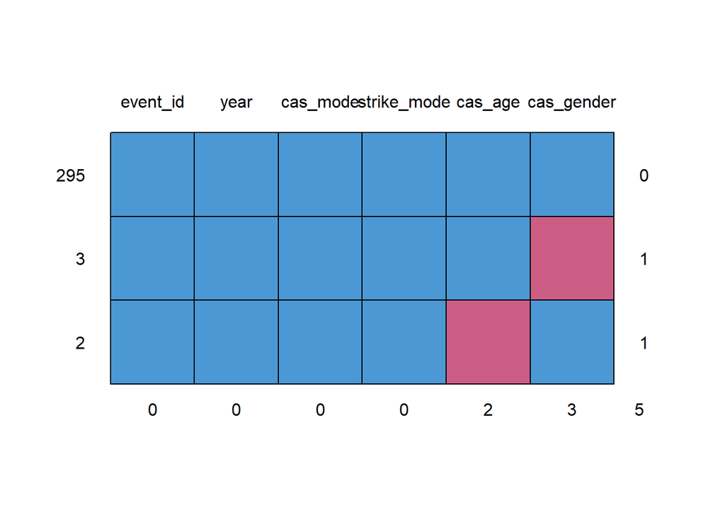

```
##     event_id year cas_mode strike_mode cas_age cas_gender
## 295        1    1        1           1       1          1 0
## 3          1    1        1           1       1          0 1
## 2          1    1        1           1       0          1 1
##            0    0        0           0       2          3 5
```

```r
md.pattern(whw)
```

```r
# Imputation using mice. I imputed the dataset 5 times (this is why is multiple
# imputation). The idea is to make a sensitivity analysis in the results.
imp1 <- mice(whw[,c("year","cas_gender", "cas_age", "cas_mode", "strike_mode")],
             m = 5, seed = 12345)
imp1
```

```
## Class: mids
## Number of multiple imputations:  5
## Imputation methods:
##        year  cas_gender     cas_age    cas_mode strike_mode
##          ""    "logreg"       "pmm"          ""          ""
## PredictorMatrix:
##             year cas_gender cas_age cas_mode strike_mode
## year           0          1       1        1           1
## cas_gender     1          0       1        1           1
## cas_age        1          1       0        1           1
## cas_mode       1          1       1        0           1
## strike_mode    1          1       1        1           0
```

```r
whw <- whw %>% rename(cas_age_original = cas_age,
                      cas_gender_original = cas_gender) %>%
  bind_cols(complete(imp1) %>% dplyr::select(cas_age, cas_gender))

whw$cas_mode <- smodes$exhaustive_list[match(tolower(whw$cas_mode),
                                             smodes$original)]
whw$strike_mode <- smodes$exhaustive_list[match(tolower(whw$strike_mode),
                                                smodes$original)]

unique(whw$cas_mode) %in% smodes$exhaustive_list
```

```
## [1] TRUE TRUE TRUE TRUE TRUE TRUE
```

```r
unique(whw$strike_mode) %in% smodes$exhaustive_list
```

```
## [1] TRUE TRUE TRUE TRUE TRUE TRUE TRUE TRUE
```

```r
# Export file
#write_csv(whw, 'C:/Users/danie/Documents/Daniel_Gil/Consultorias/2020/WorldBank/Data/Uruguay/Montevideo/Cleaned/injuries_montevideo_wb.csv')
write_csv(whw, 'inst/extdata/local/montevideo/injuries_montevideo.csv')
```